# Coursework 1

##### (f) Suppose that we wish to predict gas mileage (mpg) on the basis of the other variables. Do your plots suggest that any of the other variables might be useful in predicting mpg? Justify your answer.

According to graph predictors that looks to have relationship with mpg are: horsepower

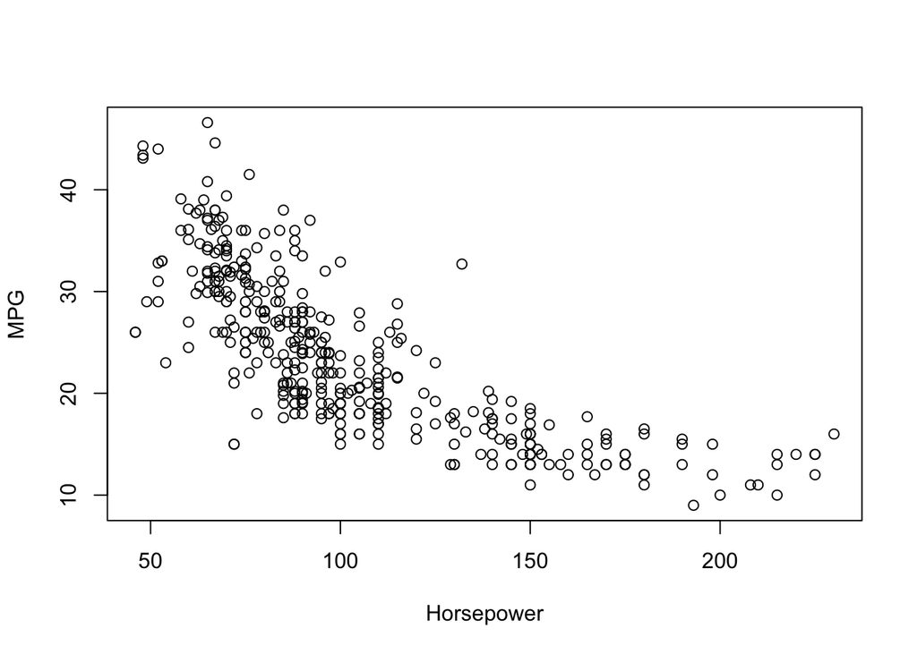

```r
plot(Auto$horsepower, Auto$mpg, xlab = "Horsepower", ylab = "MPG")
```

Weight

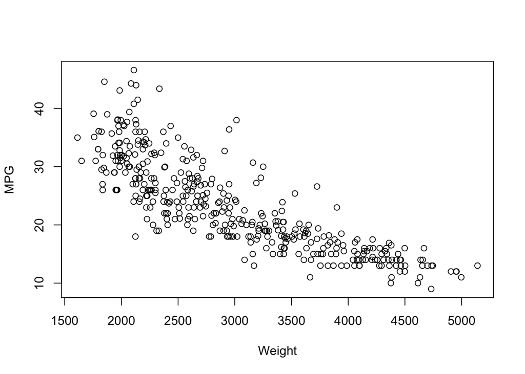

```r
plot(Auto$weight, Auto$mpg, xlab = "Weight", ylab = "MPG")
```

Displacement

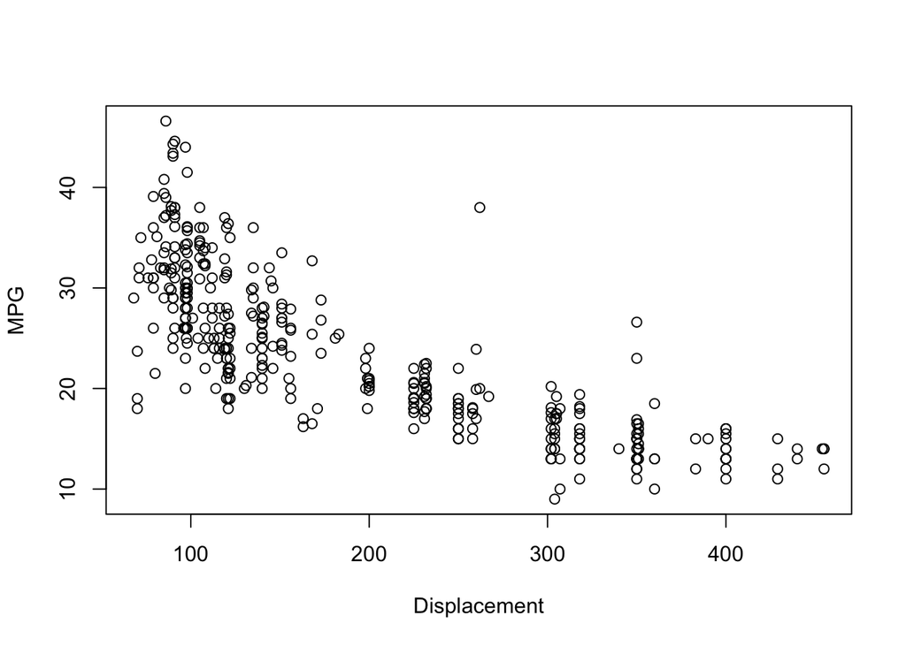

```r
plot(Auto$displacement, Auto$mpg, xlab = "Displacement", ylab = "MPG")
```

#### 4. Linear regression

This question involves the use of simple linear regression on the Auto data set.

##### (a) Use the lm() function to perform a simple linear regression with mpg as the response and horsepower as the predictor. Use the summary() function to print the results. Comment on the output. For example:

*i. Is there a relationship between the predictor and the response?*

```r
lm.fit <- lm(mpg ~ horsepower, data = Auto)
summary(lm.fit)
```

```
##
## Call:
## lm(formula = mpg ~ horsepower, data = Auto)
##
## Residuals:
##      Min       1Q   Median       3Q      Max
## -13.5710  -3.2592  -0.3435   2.7630  16.9240
##
## Coefficients:
##              Estimate Std. Error t value Pr(>|t|)
## (Intercept) 39.935861   0.717499   55.66   <2e-16 ***
## horsepower  -0.157845   0.006446  -24.49   <2e-16 ***
## ---
## Signif. codes:  0 '***' 0.001 '**' 0.01 '*' 0.05 '.' 0.1 ' ' 1
##
## Residual standard error: 4.906 on 390 degrees of freedom
## Multiple R-squared:  0.6059, Adjusted R-squared:  0.6049
## F-statistic: 599.7 on 1 and 390 DF,  p-value: < 2.2e-16
```

*ii. How strong is the relationship between the predictor and the response?*

*iii. Is the relationship between the predictor and the response positive or negative?*

Negative

*iv. What is the predicted mpg associated with a horsepower of 98? What are the associated 95% confidence and prediction intervals?*

```r
print(paste("Confidence interval,", predict(lm.fit, data.frame(horsepower=98), interval="confidence")))
```

```
## [1] "Confidence interval, 24.4670771525124"
## [2] "Confidence interval, 23.9730789607039"
## [3] "Confidence interval, 24.9610753443209"
```

```r
print(paste("Prediction from model,", predict(lm.fit, data.frame(horsepower=98), interval="prediction")))
```

```
## [1] "Prediction from model, 24.4670771525124"
## [2] "Prediction from model, 14.8093960709667"
## [3] "Prediction from model, 34.1247582340581"
```

##### (b) Plot the response and the predictor. Use the abline() function to display the least squares regression line.

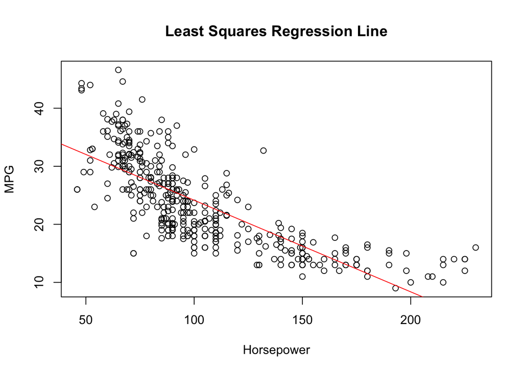

```r
plot(Auto$horsepower, Auto$mpg, xlab = "Horsepower", ylab = "MPG", main = "Least Squares Regression Line")
abline(lm.fit, col= 'red')
```

##### (c) Plot the 95% confidence interval and prediction interval in the same plot as (b) using different colours and legends.

[figure not shown]

```r
plot(Auto$horsepower, Auto$mpg, xlab = "Horsepower", ylab = "MPG", main = "95% confidence interval and prediction interval", pch = 19)
abline(lm.fit, col= 'lightblue')
new_x <- seq(min(Auto$horsepower), max(Auto$horsepower), by = 0.05)
conf_inteval <- predict(lm.fit, newdata = data.frame(horsepower=new_x), interval = "confidence", level = 0.95)
lines(new_x, conf_inteval[,2], col = "red", lty=2)
lines(new_x, conf_inteval[,3], col = "red", lty=2)
legend("topright", col = c("black", "lightblue", "red"), legend = c("Data Points", "Prediction Line", "confidence interval"), pch = c(19, NA, NA), lty = c(NA, 1, 2))
```

#### 5. Logistic regression

Using the Boston data set, fit classification models in order to predict whether a given suburb has a crime rate above or below the median. Explore logistic regression models using various subsets of the predictors. Describe your findings.

```r
library("MASS")
median_crime <- median(Boston$crim)
median_crime
```

```
## [1] 0.25651
```

First I will create new response variable called “highcrim” and populate it with TRUE if crime rate is above median and FALSE if its below median.

```r
Boston$highcrim <- Boston$crim > median_crime
head(Boston)
```

```
##      crim zn indus chas   nox    rm  age    dis rad tax ptratio  black
## 1 0.00632 18  2.31    0 0.538 6.575 65.2 4.0900   1 296    15.3 396.90
## 2 0.02731  0  7.07    0 0.469 6.421 78.9 4.9671   2 242    17.8 396.90
## 3 0.02729  0  7.07    0 0.469 7.185 61.1 4.9671   2 242    17.8 392.83
## 4 0.03237  0  2.18    0 0.458 6.998 45.8 6.0622   3 222    18.7 394.63
## 5 0.06905  0  2.18    0 0.458 7.147 54.2 6.0622   3 222    18.7 396.90
## 6 0.02985  0  2.18    0 0.458 6.430 58.7 6.0622   3 222    18.7 394.12
##   lstat medv highcrim
## 1  4.98 24.0    FALSE
## 2  9.14 21.6    FALSE
## 3  4.03 34.7    FALSE
## 4  2.94 33.4    FALSE
## 5  5.33 36.2    FALSE
## 6  5.21 28.7    FALSE
```

We can first create logistic regression model with all the predictors (except crim) and observe which predictors have high importance.

```r
glm.fit <- glm(highcrim ~ . -crim, data = Boston, family = "binomial")
summary(glm.fit)
```

```
##
## Call:
## glm(formula = highcrim ~ . - crim, family = "binomial", data = Boston)
##
## Deviance Residuals:
##     Min       1Q   Median       3Q      Max
## -2.3946  -0.1585  -0.0004   0.0023   3.4239
##
## Coefficients:
##               Estimate Std. Error z value Pr(>|z|)
## (Intercept) -34.103704   6.530014  -5.223 1.76e-07 ***
## zn           -0.079918   0.033731  -2.369  0.01782 *
## indus        -0.059389   0.043722  -1.358  0.17436
## chas          0.785327   0.728930   1.077  0.28132
## nox          48.523782   7.396497   6.560 5.37e-11 ***
## rm           -0.425596   0.701104  -0.607  0.54383
## age           0.022172   0.012221   1.814  0.06963 .
## dis           0.691400   0.218308   3.167  0.00154 **
## rad           0.656465   0.152452   4.306 1.66e-05 ***
## tax          -0.006412   0.002689  -2.385  0.01709 *
## ptratio       0.368716   0.122136   3.019  0.00254 **
## black        -0.013524   0.006536  -2.069  0.03853 *
## lstat         0.043862   0.048981   0.895  0.37052
## medv          0.167130   0.066940   2.497  0.01254 *
## ---
## Signif. codes:  0 '***' 0.001 '**' 0.01 '*' 0.05 '.' 0.1 ' ' 1
##
## (Dispersion parameter for binomial family taken to be 1)
##
##     Null deviance: 701.46  on 505  degrees of freedom
## Residual deviance: 211.93  on 492  degrees of freedom
## AIC: 239.93
##
## Number of Fisher Scoring iterations: 9
```

Statisticly high importance predictors are the ones with large z-statistics and small p-values (<0.05). Some of these variables are: nox rad dis ptratio mdv It is usually good practice to visulise these variables to confirm the relationship. I will choose variable dis to demonstrade.

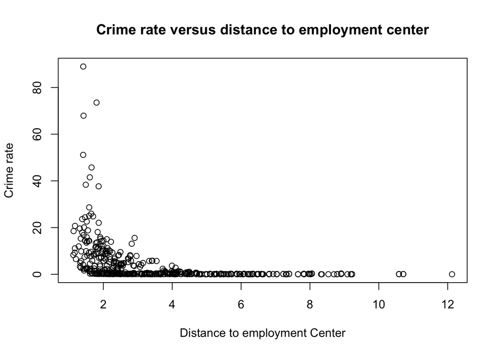

```r
plot(Boston$dis, Boston$crim, main = "Crime rate versus distance to employment center", xlab = "Distance to employment Center", ylab = "Crime rate")
```

Relationship between the two looks logarithmmic, in fact log transfor of two resables linear relationship.

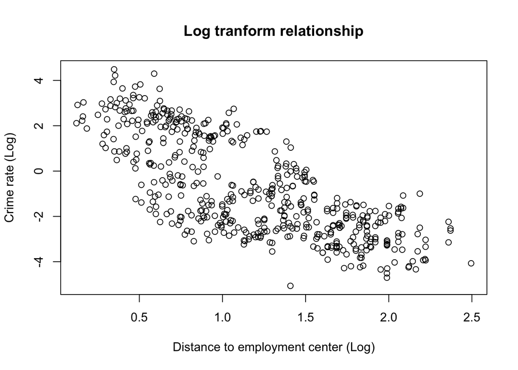

```r
plot(log(Boston$dis), log(Boston$crim), main = "Log tranform relationship", xlab = "Distance to employment center (Log)", ylab = "Crime rate (Log)")
```

We can refit a model with selected predictors and observe the predictions.

```r
selected.glm <- glm(highcrim ~nox + rad + dis + ptratio + medv , data = Boston, family = "binomial")
first_model_prob <- predict(glm.fit, type = "response")
first_model <- rep(1, nrow(Boston))
first_model[first_model_prob < 0.5] <- 0
second_model_prob <- predict(selected.glm, type = "response")
second_model <- rep(1, nrow(Boston))
second_model[second_model_prob < 0.5] <- 0
```

```r
table(first_model, Boston$highcrim)
```

```
##
## first_model FALSE TRUE
##           0   234   24
##           1    19  229
```

```r
mean(first_model != Boston$highcrim)
```

```
## [1] 0.08498024
```

```r
table(second_model, Boston$highcrim)
```

```
##
## second_model FALSE TRUE
##            0   236   43
##            1    17  210
```

```r
mean(second_model != Boston$highcrim)
```

```
## [1] 0.1185771
```

#### 6. Resampling methods

Suppose that we use some statistical learning method to make a prediction for the response Y for a particular value of the predictor X. Carefully describe how we might estimate the standard deviation of our prediction.

We can estimate standard deviation of our prediction using bootstrap method. Insted of obtaining new data sets, we randomly sample our original data set with replacement and we can estimate our standard deviation with those samples. If we sample data B time and find the corresponding estimates and standard deviation of those B samples, we can estimate the standard deviation with following equation.
$$SD(\hat{\theta}) = \sqrt{\frac{1}{B-1}\sum_{b=1}^{B}(\hat{\theta}_b-\bar{\theta})^2}$$
where
$$\bar{\theta} = (\frac{1}{B}) \sum_{b=1}^{B} \hat{\theta}_b$$

#### 7. Resampling methods

We will now perform cross-validation on a simulated data set.

##### (a) Generate a simulated data set as follows:

```r
set.seed(500)
y = rnorm(500)
x = 4 - rnorm(500)
y = x - 2*x^2 + 3*x^4 + rnorm(500)
```

In this data set, what is n and what is p? Write out the model used to generate the data in equation form.

From question above n is 500 and p is equal to 4. The model is $y = x - 2 x^2 + 3 x^4 + \epsilon$ and $\epsilon$ is random noise that produced by rnorm(500).

##### (b) Create a scatterplot of X against Y. Comment on what you find.

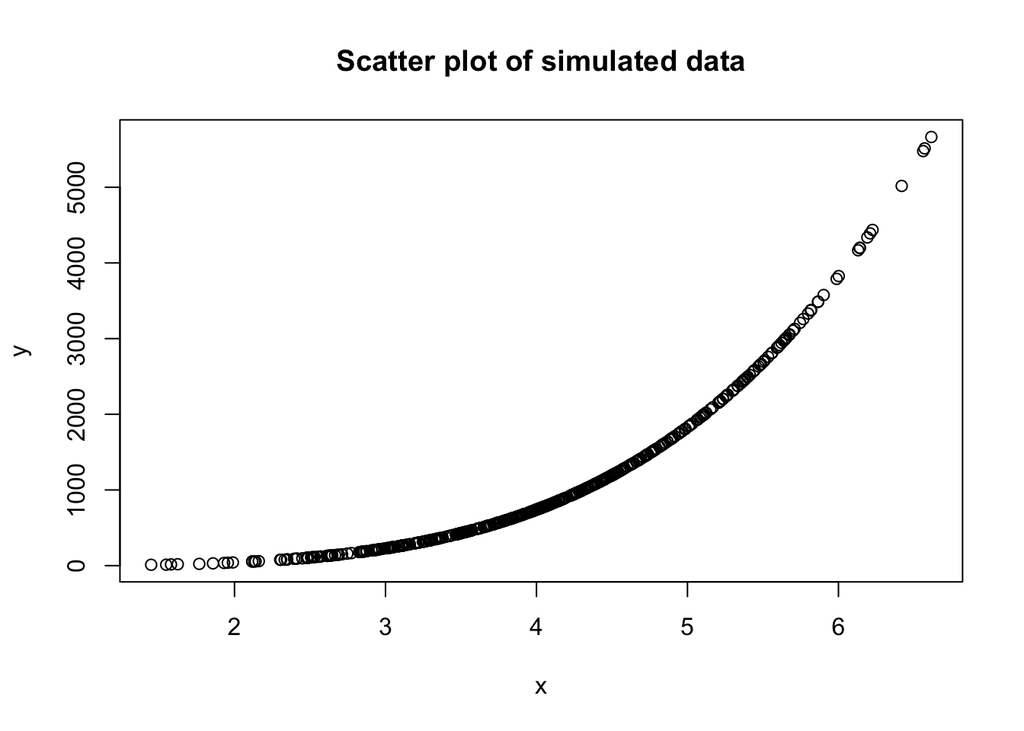

```r
plot(x, y, main = "Scatter plot of simulated data")
```

We can clearly observe polinomial relationship between x and y.

##### (c) Set the seed to be 23, and then compute the LOOCV and 10-fold CV errors that result from fitting the following four models using least squares:

```r
library(boot)
set.seed(23)
y = rnorm(500)
x = 4 - rnorm(500)
y = x - 2 * x^2 + 3 * x^4 + rnorm(500)
df <- data.frame(x, y)
```

1. Y = β0 + β1X + ε

```r
fit.glm.1 <- glm(y ~ x, data = df)
cv.loocv <- cv.glm(df, fit.glm.1)
print(paste("LOOCV error,",cv.loocv$delta[1]))
```

```
## [1] "LOOCV error, 195337.297150242"
```

```r
cv.10 <- cv.glm(df, fit.glm.1, K=10)
print(paste("10 fold error,",cv.10$delta[1]))
```

```
## [1] "10 fold error, 193314.650140994"
```

2. Y =β0 +β1X+β2X2 +ε

```r
fit.glm.2 <- glm(y ~ poly(x, 2), data=df)
cv.loocv2 <- cv.glm(df, fit.glm.2)
print(paste("LOOCV error,", cv.loocv2$delta[1]))
```

```
## [1] "LOOCV error, 11865.4098083307"
```

```r
cv.10k2 <- cv.glm(df, fit.glm.2 ,K=10)
print(paste("10 fold error,", cv.10k2$delta[1]))
```

```
## [1] "10 fold error, 12018.4546211805"
```

3. Y =β0 +β1X+β2X2 +β3X3 +ε

```r
fit.glm.3 <- glm(y ~ poly(x, 3), data=df)
cv.loocv3 <- cv.glm(df, fit.glm.3)
print(paste("LOOCV error,", cv.loocv3$delta[1]))
```

```
## [1] "LOOCV error, 151.481840745371"
```

```r
cv.10k3 <- cv.glm(df, fit.glm.3 ,K=10)
print(paste("10 fold error,", cv.10k3$delta[1]))
```

```
## [1] "10 fold error, 157.890934227381"
```

4. Y =β0 +β1X+β2X2 +β3X3 +β4X4 +ε.

```r
fit.glm.4 <- glm(y ~ poly(x, 4), data=df)
cv.loocv4 <- cv.glm(df, fit.glm.4)
print(paste("LOOCV error,", cv.loocv4$delta[1]))
```

```
## [1] "LOOCV error, 1.04678407691067"
```

```r
cv.10k4 <- cv.glm(df, fit.glm.4 ,K=10)
print(paste("10 fold error,", cv.10k4$delta[1]))
```

```
## [1] "10 fold error, 1.05923599962825"
```

Note you may find it helpful to use the data.frame() function to create a single data set containing both X and Y.

##### (d) Repeat (c) using random seed 46, and report your results. Are your results the same as what you got in (c)? Why?

```r
set.seed(46)
y = rnorm(500)
x = 4 - rnorm(500)
y = x - 2 * x^2 + 3 * x^4 + rnorm(500)
df <- data.frame(x, y)
for (i in 1:4){
  print(paste("Fitting model with polinomial degree", i))
  model.fit <- glm(y ~ poly(x, i), data=df)
  print(paste("LOOCV error,", cv.glm(df, model.fit)$delta[1]))
  print(paste("10 fold error,", cv.glm(df, model.fit, K=10)$delta[1]))
}
```

```
## [1] "Fitting model with polinomial degree 1"
## [1] "LOOCV error, 212789.740894727"
## [1] "10 fold error, 212191.155996556"
## [1] "Fitting model with polinomial degree 2"
## [1] "LOOCV error, 12646.1993515859"
## [1] "10 fold error, 13106.3094597804"
## [1] "Fitting model with polinomial degree 3"
## [1] "LOOCV error, 134.149872021206"
## [1] "10 fold error, 137.344748362639"
## [1] "Fitting model with polinomial degree 4"
## [1] "LOOCV error, 1.04686061344976"
## [1] "10 fold error, 1.05772631695904"
```

Errors are not the same because random noise generated by `rnorm(500)` if different when seed set to 46.

##### (e) Which of the models in (c) had the smallest LOOCV and 10-fold CV error? Is this what you expected? Explain your answer.

Model number 4 has the lowest error rate. It is expected because we generated y as a degree 4 polinomial in the $y = 3 x^4 - 2 x^2 + x + \epsilon$ and degree 4 polinomial predictor fits the data best.

##### (f) Comment on the statistical significance of the coefficient estimates that results from fitting each of the models in (c) using least squares. Do these results agree with the conclusions drawn based on the cross-validation results?

```r
fit.glm.4 <- glm(y ~ poly(x, 4), data=df)
summary(fit.glm.4)
```

```
##
## Call:
## glm(formula = y ~ poly(x, 4), data = df)
##
## Deviance Residuals:
##     Min       1Q   Median       3Q      Max
## -2.9713  -0.5827  -0.0337   0.6461   3.5006
##
## Coefficients:
##              Estimate Std. Error t value Pr(>|t|)
## (Intercept) 1.092e+03  4.541e-02 24041.6   <2e-16 ***
## poly(x, 4)1 2.182e+04  1.015e+00 21486.5   <2e-16 ***
## poly(x, 4)2 9.914e+03  1.015e+00  9763.2   <2e-16 ***
## poly(x, 4)3 2.404e+03  1.015e+00  2367.9   <2e-16 ***
## poly(x, 4)4 2.313e+02  1.015e+00   227.8   <2e-16 ***
## ---
## Signif. codes:  0 '***' 0.001 '**' 0.01 '*' 0.05 '.' 0.1 ' ' 1
##
## (Dispersion parameter for gaussian family taken to be 1.031068)
##
##     Null deviance: 5.8013e+08  on 499  degrees of freedom
## Residual deviance: 5.1038e+02  on 495  degrees of freedom
## AIC: 1441.2
##
## Number of Fisher Scoring iterations: 2
```

T value reduces significanly while we go from liner to cubic or 4th degree, this strongly agrees with our cross validation results.